# Calcule_StochFinale2

#### PUT

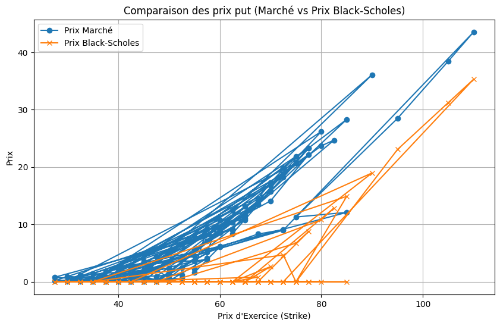

```python
plt.figure(figsize=(10, 6))
plt.plot(put['Strike price'], put['Price'], label='Prix Marché', marker='o')
plt.plot(put['Strike price'], put['Prix Black-Scholes'], label='Prix Black-Scholes', marker='x')
plt.xlabel('Prix d\'Exercice (Strike)')
plt.ylabel('Prix')
plt.title('Comparaison des prix put (Marché vs Prix Black-Scholes)')
plt.legend()
plt.grid()
plt.show()
```

La comparaison entre les prix des options Put estimés par le modèle de Black-Scholes et les prix observés sur le marché en fonction des prix d’exercice nous montre que les courbes représentant les prix du marché sont significativement plus élevées que celles issues du modèle, notamment pour les options avec des strikes plus élevés. Cela indique que le modèle de Black-Scholes sous-estime les prix des options Put sur une large plage de strikes. Ce décalage est particulièrement marqué dans les zones où la volatilité implicite joue un rôle important, comme les options "hors de la monnaie" (strikes élevés). Le modèle Black-Scholes échoue à capturer les variations dynamiques de la volatilité implicite observées sur les marchés, ce qui explique ces écarts.

## Modèle de Heston

### Théorie

Le modèle de Heston est une extension du modèle de Black-Scholes, prenant en compte une volatilité stochastique. Il est largement utilisé en finance pour le pricing des options, en particulier lorsque la volatilité du marché n'est pas constante.

Hypothèses et Formulation

Le modèle repose sur deux équations différentielles stochastiques :

1. Le prix de l'actif sous-jacent suit : $$ dS_t = \mu S_t dt + \sqrt{v_t} S_t dW_t^S $$ où :
   - $(S_t$) est le prix de l'actif sous-jacent,
   - $(\mu$) est le taux de rendement espéré,
   - $(v_t$) est la variance instantanée,
   - $(dW_t^S$) est un mouvement brownien.
2. La variance suit un processus CIR (Cox-Ingersoll-Ross) : $$ dv_t = \kappa(\theta - v_t)dt + \sigma_v \sqrt{v_t} dW_t^v $$ où :
   - $(\kappa$) est le taux de reversion vers la moyenne,
   - $(\theta$) est la variance à long terme,
   - $(\sigma_v$) est la volatilité de la variance,
   - $(dW_t^v$) est un mouvement brownien corrélé à $(dW_t^S$) ($(\rho$) est le coefficient de corrélation).

Avantages du modèle

- Intègre une volatilité stochastique, ce qui permet de capturer le "volatility smile" observé sur les marchés.
- Gère les corrélations entre le prix de l'actif et sa volatilité via le paramètre $(\rho$).

Limites

- Complexité des calculs analytiques, nécessitant souvent des approches numériques (FFT, Monte Carlo).
- Sensibilité à l'estimation des paramètres, notamment $(\kappa$), $(\theta$), et $(\sigma_v$).

Applications Le modèle de Heston est principalement utilisé pour :

1. Pricing des options européennes et exotiques.
2. Analyse de la volatilité implicite et ajustement des prix de marché.

En résumé, le modèle de Heston offre une alternative réaliste et flexible au modèle de Black-Scholes en permettant une volatilité non constante et corrélée au prix de l'actif.